# CA2 Ionosphere Data

```r
print(model)
```

```
## n= 246
##
## node), split, n, loss, yval, (yprob)
##       * denotes terminal node
##
##  1) root 246 87 good (0.35365854 0.64634146)
##    2) V5< 0.145975 51  1 bad (0.98039216 0.01960784) *
##    3) V5>=0.145975 195 37 good (0.18974359 0.81025641)
##      6) V27>=0.999945 35  7 bad (0.80000000 0.20000000)
##       12) V21< 0.99242 15  0 bad (1.00000000 0.00000000) *
##       13) V21>=0.99242 20  7 bad (0.65000000 0.35000000)
##         26) V4< -0.517605 8  0 bad (1.00000000 0.00000000) *
##         27) V4>=-0.517605 12  5 good (0.41666667 0.58333333) *
##      7) V27< 0.999945 160  9 good (0.05625000 0.94375000) *
```

```r
#There are 5 terminal nodes
```

6. Use the predict function to find the predicted values for the test dataset. Create a confusion matrix.  
   What is the accuracy of this model?

Accuracy : 0.8667  
Sensitivity : 0.9394  
This indicates that it can correctly identify 93.94% of ‘good’ radar.  
Correctly predicted 62 true positives.  
Specificity : 0.7436  
This indicates that it can correctly identify 74.36% of ‘bad’ radar.  
Correctly predicted 29 true negatives.

95% of the time our true accuracy should lie between 0.7864, 0.9251.

```r
#Generate predicted classes for test data using the model
class_pred <- predict(object = model,  newdata = Ionosphere_test, type =
                            "class")
#Create confusion matrix with positive set to good
confusionMatrix(data = class_pred,  reference = Ionosphere_test$Class, positive =
                      "good")
```

```
## Confusion Matrix and Statistics
##
##           Reference
## Prediction bad good
##       bad   29    4
##       good  10   62
##
##                Accuracy : 0.8667
##                  95% CI : (0.7864, 0.9251)
##     No Information Rate : 0.6286
##     P-Value [Acc > NIR] : 5.206e-08
##
##                   Kappa : 0.7052
##
##  Mcnemar's Test P-Value : 0.1814
##
##             Sensitivity : 0.9394
##             Specificity : 0.7436
##          Pos Pred Value : 0.8611
##          Neg Pred Value : 0.8788
##              Prevalence : 0.6286
##          Detection Rate : 0.5905
##    Detection Prevalence : 0.6857
##       Balanced Accuracy : 0.8415
##
##        'Positive' Class : good
##
```

```r
#Accuracy : 0.8667
#Sensitivity : 0.9394
#Specificity : 0.7436
```

7. Create a ROC plot to show the sensitivity vs specificity of the model.  
   Find the Area Under the Curve (AUC). Interpret this.

Area under the curve: 0.8619  
This plot allows us to visually see the Accuracy, Sensitivity and Specificity as discussed in part (f).

```r
#Generate predicted probabilities for bad, good using the model
levels(Ionosphere_Data$Class)
```

```
## [1] "bad"  "good"
```

```r
tree_preds_prob <- predict(model, Ionosphere_test,
  type="prob")[, 2] #Probability of predicting 'good'
ROC <- roc(Ionosphere_test$Class, tree_preds_prob,
                               levels=c("bad","good"))
```

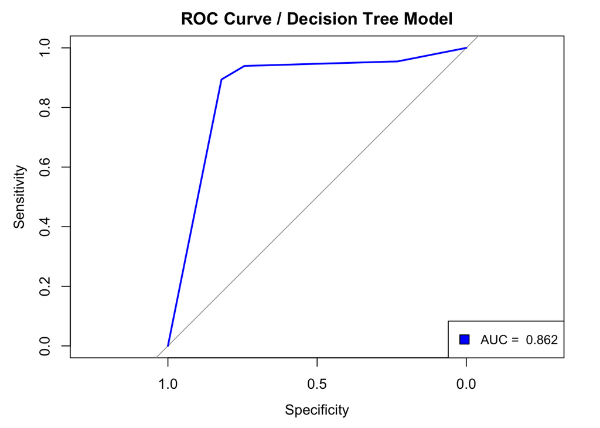

```r
#Plot the ROC curve
plot(ROC, col = 'blue', main = "ROC Curve / Decision Tree Model")
legend("bottomright",fill = c("blue"),
       legend = c(paste("AUC = ",round(ROC$auc,3))),
       cex = 0.9)
```

```r
#Calculate the area under the curve (AUC)
ROC$auc
```

```
## Area under the curve: 0.8619
```

```r
#Area under the curve: 0.8619
```

Ensemble techniques Trees:  
(h)  
Use the bagging function on the training data to predict Class.  
What are the important variables used in this technique.

The most important variables using this technique are:  
V27 with 68.66 relative influence  
V5 with 63.56 relative influence  
V3 with 59.7 relative influence  
V7 with 57.63 relative influence

```r
bagged_model <- bagging(formula = Class ~ .,
                        data = Ionosphere_train,
                        coob = TRUE)
varImp(bagged_model)
```

```
##        Overall
## V1  16.5365259
## V10  4.7711169
## V11  0.9741500
## V12  6.3948086
## V13  0.9121732
## V14  8.4550288
## V15  1.1125355
## V16 11.5543027
## V17  2.4426036
## V18  5.4409560
## V19  1.7183892
## V20  4.5875286
## V21  3.7621336
## V22 12.6403113
## V23  2.6329110
## V24 12.2397961
## V25  1.5072044
## V26  2.9723952
## V27 68.6674558
## V28  5.1154657
## V29 11.0084180
## V3  59.7407919
## V30  3.7651233
## V31  5.5978247
## V32  2.3137024
## V33  6.6412216
## V34  3.9560032
## V4  19.4654687
## V5  63.5667844
## V6  14.3277497
## V7  57.6357174
## V8  14.0140722
## V9   4.9237772
```

```r
print(bagged_model)
```

```
##
## Bagging classification trees with 25 bootstrap replications
##
## Call: bagging.data.frame(formula = Class ~ ., data = Ionosphere_train,
##     coob = TRUE)
##
## Out-of-bag estimate of misclassification error:  0.0813
```

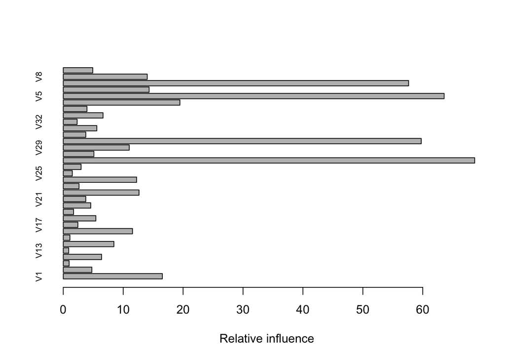

```r
var_info=varImp(bagged_model)
barplot(var_info$Overall,horiz =TRUE, names.arg = row.names(var_info),xlab="Relative influence",cex.names=0.7)
```

1. Use the predict function to find the predicted values for the test dataset using the model in (h).  
   Create a confusion matrix.  
   What is the accuracy of this model?

Accuracy : 0.9048  
Sensitivity : 0.9545  
This indicates that it can correctly identify 95.45% of ‘good’ radar.  
Correctly predicted 63 true positives.  
Specificity : 0.8205  
This indicates that it can correctly identify 82.05% of ‘bad’ radar.  
Correctly predicted 32 true negatives.

95% of the time our true accuracy should lie between 0.8318, 0.9534.

```r
#Generate predicted classes for test data using the model
class_pred <- predict(object = bagged_model,  newdata = Ionosphere_test, type =
                        "class")
#Create confusion matrix with positive set to good
confusionMatrix(data = class_pred,  reference = Ionosphere_test$Class, positive =
                  "good")
```

```
## Confusion Matrix and Statistics
##
##           Reference
## Prediction bad good
##       bad   32    3
##       good   7   63
##
##                Accuracy : 0.9048
##                  95% CI : (0.8318, 0.9534)
##     No Information Rate : 0.6286
##     P-Value [Acc > NIR] : 1.215e-10
##
##                   Kappa : 0.7917
##
##  Mcnemar's Test P-Value : 0.3428
##
##             Sensitivity : 0.9545
##             Specificity : 0.8205
##          Pos Pred Value : 0.9000
##          Neg Pred Value : 0.9143
##              Prevalence : 0.6286
##          Detection Rate : 0.6000
##    Detection Prevalence : 0.6667
##       Balanced Accuracy : 0.8875
##
##        'Positive' Class : good
##
```

```r
#Accuracy : 0.9048
#Sensitivity : 0.9545
#Specificity : 0.8205
```

10. Use the random forest technique on the training data to predict Class.  
    What are the important variables used in this technique.

The most important variables using this technique are:  
V5 with 16.18 relative influence  
V27 with 10.83 relative influence V3 with 9.39 relative influence V7 with 8.33 relative influence

```r
rf_model <- randomForest(formula =  Class ~ .,
                         data = Ionosphere_train)
varImp(rf_model)
```

```
##        Overall
## V1   3.0423277
## V3   9.3901724
## V4   3.8885327
## V5  16.1861974
## V6   3.9578136
## V7   8.3366238
## V8   3.9967703
## V9   1.4584536
## V10  1.9538362
## V11  0.8181773
## V12  2.0675333
## V13  0.7917586
## V14  3.4795721
## V15  1.8041556
## V16  3.5969873
## V17  0.9732101
## V18  3.0572294
## V19  0.6580511
## V20  1.7380827
## V21  2.4579302
## V22  1.9852248
## V23  1.3359386
## V24  3.9344047
## V25  1.0081049
## V26  1.6343229
## V27 10.8337276
## V28  2.3339952
## V29  4.5173081
## V30  0.9380787
## V31  3.4066585
## V32  1.3350524
## V33  3.2046634
## V34  1.9592511
```

```r
print(rf_model)
```

```
##
## Call:
##  randomForest(formula = Class ~ ., data = Ionosphere_train)
##                Type of random forest: classification
##                      Number of trees: 500
## No. of variables tried at each split: 5
##
##         OOB estimate of  error rate: 6.91%
## Confusion matrix:
##      bad good class.error
## bad   77   10  0.11494253
## good   7  152  0.04402516
```

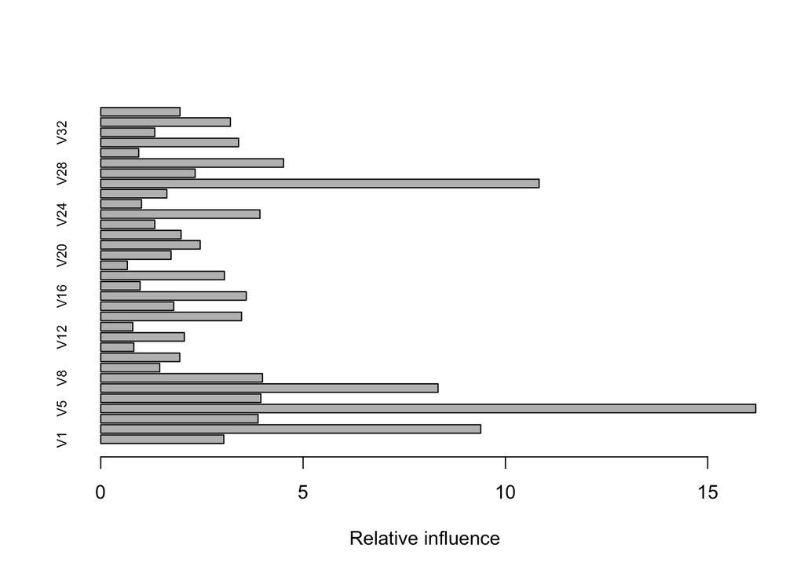

```r
var_info=varImp(rf_model)
barplot(var_info$Overall,horiz =TRUE, names.arg = row.names(var_info),xlab="Relative influence",cex.names=0.7)
```

```r
#All variables are important using this technique
```

11. Use the plot function on your output of the randomForest function in (j).  
    What does it tell you?

It looks as though error is the lowest with around 42 trees.  
We can confirm this using the “which.min” function and call information from “err.rate” in our model.

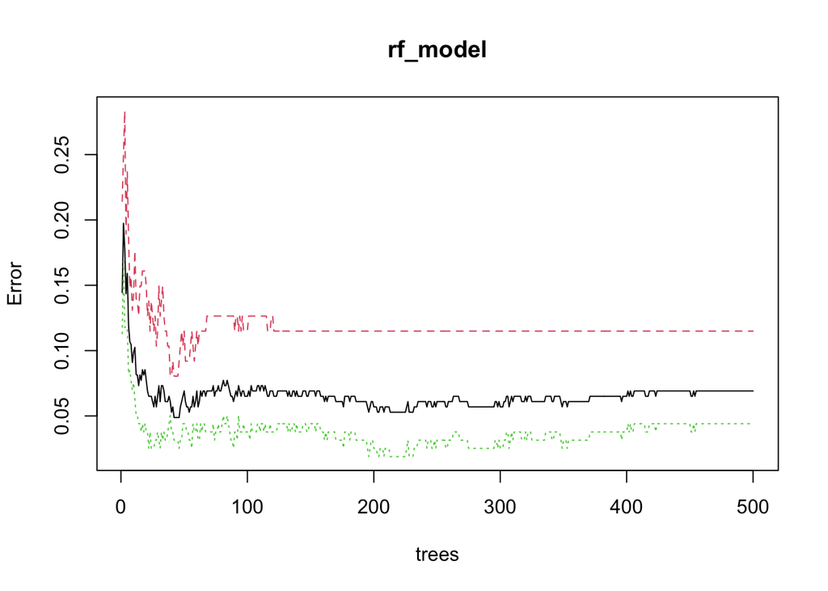

```r
plot(rf_model)
```

```r
which.min(rf_model$err.rate[,1])
```

```
## [1] 42
```

12. Predict the response for the test set and create the confusion matrix and calculate the accuracy.  
    How does it compare with the model obtained for bagging in part (h)?

Accuracy : 0.9143 Sensitivity : 0.9545  
This indicates that it can correctly identify 95.45% of ‘good’ radar.  
Correctly predicted 63 true positives.  
Specificity : 0.8462  
This indicates that it can correctly identify 84.62% of ‘bad’ radar.  
Correctly predicted 33 true negatives.

95% of the time our true accuracy should lie between 0.8435, 0.9601.

This random forest model is better at predicting true negatives than our bagged model in part (i).

```r
#Generate predicted classes for test data using the model
rf_class_pred <- predict(object = rf_model,  newdata = Ionosphere_test, type =
                        "class")
#Create confusion matrix with positive set to good
confusionMatrix(data = rf_class_pred,  reference = Ionosphere_test$Class, positive =
                  "good")
```

```
## Confusion Matrix and Statistics
##
##           Reference
## Prediction bad good
##       bad   33    3
##       good   6   63
##
##                Accuracy : 0.9143
##                  95% CI : (0.8435, 0.9601)
##     No Information Rate : 0.6286
##     P-Value [Acc > NIR] : 2.095e-11
##
##                   Kappa : 0.8135
##
##  Mcnemar's Test P-Value : 0.505
##
##             Sensitivity : 0.9545
##             Specificity : 0.8462
##          Pos Pred Value : 0.9130
##          Neg Pred Value : 0.9167
##              Prevalence : 0.6286
##          Detection Rate : 0.6000
##    Detection Prevalence : 0.6571
##       Balanced Accuracy : 0.9003
##
##        'Positive' Class : good
##
```

```r
#Accuracy : 0.9143
#Sensitivity : 0.9545
#Specificity : 0.8462
```

13. Perform boosting on the training data to predict Class.  
    What are the important variables used in this technique.

The most important variables using this technique are: V5 with 22.08 relative influence V27 with 20.83 relative influence  
V7 with 13.4 relative influence  
V3 with 9.6 relative influence

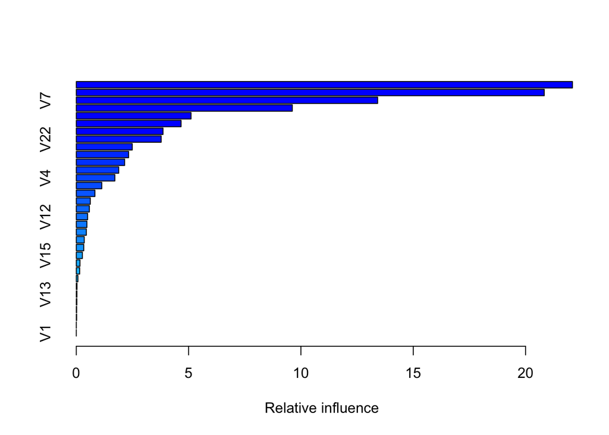

```
##     var       rel.inf
## V5   V5 22.0885411274
## V27 V27 20.8331307089
## V7   V7 13.4161592139
## V3   V3  9.6171457960
## V8   V8  5.1082532916
## V24 V24  4.6642740147
## V14 V14  3.8605577844
## V22 V22  3.7787436069
## V29 V29  2.4911078803
## V6   V6  2.3282780575
## V10 V10  2.1525870632
## V16 V16  1.8894027432
## V4   V4  1.7171087640
## V23 V23  1.1343916795
## V26 V26  0.8285797754
## V34 V34  0.6246932480
## V25 V25  0.5820653754
## V12 V12  0.5040808335
## V32 V32  0.4722947465
## V18 V18  0.4476011959
## V33 V33  0.3533848566
## V17 V17  0.3315964370
## V15 V15  0.2701875019
## V21 V21  0.1638976767
## V9   V9  0.1503393341
## V20 V20  0.0713077122
## V30 V30  0.0315728248
## V13 V13  0.0272807635
## V28 V28  0.0246781889
## V11 V11  0.0179858192
## V31 V31  0.0179556921
## V19 V19  0.0008162868
## V1   V1  0.0000000000
```

```r
#Turn off scientific notation
options(scipen = 999)
#Needs to be set up as binary variable
Ionosphere_train_gbm <- Ionosphere_train
Ionosphere_train_gbm$Class<-(as.numeric(Ionosphere_train_gbm$Class)-1)
#head(Ionosphere_train_gbm)
Ionosphere_test_gbm <- Ionosphere_test
Ionosphere_test_gbm$Class<-(as.numeric(Ionosphere_test_gbm$Class)-1)
#head(Ionosphere_test_gbm)
#Train a 5000-tree GBM model
gbm_model <- gbm(formula = Class ~ ., distribution = "bernoulli", data = Ionosphere_train_gbm, n.trees = 5000)
summary(gbm_model)
```

14. Predict the response for the test set and create a confusion matrix.  
    What is the accuracy of this model?

Accuracy : 0.8952  
Sensitivity : 0.9697  
This indicates that it can correctly identify 96.97% of ‘good’ radar.  
Correctly predicted 64 true positives.  
Specificity : 0.7692  
This indicates that it can correctly identify 76.92% of ‘bad’ radar.  
Correctly predicted 30 true negatives.

95% of the time our true accuracy should lie between 0.8203, 0.9465.

How does it compare with the bagging and the random forest models?

The accuracy of this boosting model is very similar to the accuracy of the bagged and random forest model as it is close to 90%. This model predicts the true positives better than the other models but is less accurate when predicting true negatives.

```r
#Generate predicted classes for test data using the model
gbm_class_pred <- predict(object = gbm_model,  newdata = Ionosphere_test_gbm, type =
                        "response", n.trees=5000)
#Create confusion matrix with positive set to good
gbm_class_pred <- ifelse(gbm_class_pred < 0.99, 0, 1)
gbm_class_pred <- factor(gbm_class_pred, levels = c(0, 1), labels = c("bad", "good"))

confusionMatrix(data = gbm_class_pred,  reference = Ionosphere_test$Class, positive = "good")
```

```
## Confusion Matrix and Statistics
##
##           Reference
## Prediction bad good
##       bad   30    2
##       good   9   64
##
##                Accuracy : 0.8952
##                  95% CI : (0.8203, 0.9465)
##     No Information Rate : 0.6286
##     P-Value [Acc > NIR] : 0.0000000006349
##
##                   Kappa : 0.7671
##
##  Mcnemar's Test P-Value : 0.07044
##
##             Sensitivity : 0.9697
##             Specificity : 0.7692
##          Pos Pred Value : 0.8767
##          Neg Pred Value : 0.9375
##              Prevalence : 0.6286
##          Detection Rate : 0.6095
##    Detection Prevalence : 0.6952
##       Balanced Accuracy : 0.8695
##
##        'Positive' Class : good
##
```

```r
#Accuracy : 0.8952
#Sensitivity : 0.9697
#Specificity : 0.7692
```

15. Create a ROC plot to show the sensitivity vs specificity of all the models from the previous section.  
    Find the Area Under the Curve (AUC) for each. Interpret this.

Decision Tree Model  
Area under the curve: 0.8619

Bagged Model  
Area under the curve: 0.9555

Random Forest Model  
Area under the curve: 0.9777

Boosting Model  
Area under the curve: 0.9662

The Random Forest Model is the better model as the area under the curve is closer to 1 which would be a perfect model.

```r
#Generate predicted probabilities for bad, good using the model
levels(Ionosphere_Data$Class)
```

```
## [1] "bad"  "good"
```

```r
tree_preds_prob <- predict(model, Ionosphere_test,
                           type="prob")[, 2] #Probability of predicting 'good'
roc1 <- roc(Ionosphere_test$Class, tree_preds_prob,
           levels=c("bad","good"))
bagged_preds_prob <- predict(bagged_model, Ionosphere_test,
                           type="prob")[, 2] #Probability of predicting 'good'
roc2 <- roc(Ionosphere_test$Class, bagged_preds_prob,
           levels=c("bad","good"))
rf_preds_prob <- predict(rf_model, Ionosphere_test,
                           type="prob")[, 2] #Probability of predicting 'good'
roc3 <- roc(Ionosphere_test$Class, rf_preds_prob,
           levels=c("bad","good"))
gbm_preds_prob <- predict(gbm_model, Ionosphere_test_gbm,
                           type="response", n.trees=5000) #Probability of predicting 'good'
roc4 <- roc(Ionosphere_test_gbm$Class, gbm_preds_prob,
           levels=c(0,1))
```

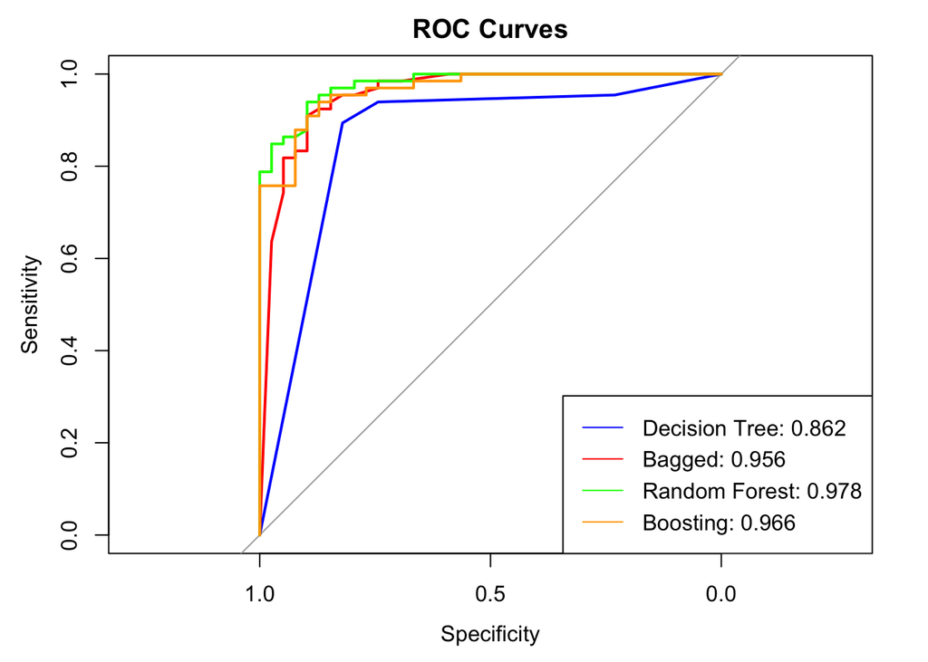

```r
# Plot the first ROC curve
plot(roc1, col = "blue", main = "ROC Curves")

# Add the second ROC curve to the same plot
lines(roc2, col = "red")
lines(roc3, col = "green")
lines(roc4, col = "orange")

# Add a legend to the plot
legend("bottomright", legend = c(paste("Decision Tree:",round(roc1$auc,3)), paste("Bagged:", round(roc2$auc,3)), paste("Random Forest:", round(roc3$auc,3)), paste("Boosting:", round(roc4$auc,3))), col = c("blue", "red", "green", "orange"), lty = 1)
```

```r
roc1$auc
```

```
## Area under the curve: 0.8619
```

```r
roc2$auc
```

```
## Area under the curve: 0.9555
```

```r
roc3$auc
```

```
## Area under the curve: 0.9777
```

```r
roc4$auc
```

```
## Area under the curve: 0.9662
```

Support Vector Machines:  
(p)  
Have a look at the data briefly, do you think a linear or radial kernel is more appropriate given the visualizations.